# Práctica Dirigida N°1 de Análisis de Regresión

Asencios Menacho Soledad

2024-09-11

# CASO 02: Empresa Azucarera del Norte

## **Análisis de Correlación**

### a) Elabore el gráfico de dispersión

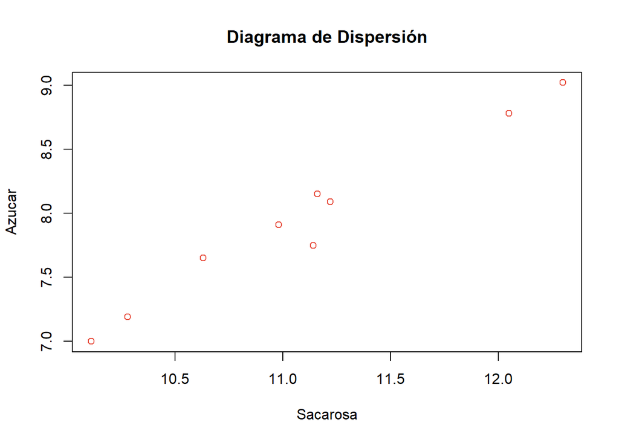

```r
plot(PD1$sacarosa, PD1$azucar,
     main = "Diagrama de Dispersión",
     col = "#e74c3c",
     xlab = "Sacarosa",
     ylab = "Azucar")
```

Se puede apreciar una relación directa entre el azucar y la sacarosa.

### b) Estime el coeficiente de correlación de Pearson.

```r
cor(PD1$sacarosa, PD1$azucar, method = "p")
```

```
## [1] 0.9852942
```

Hay una correlacion lineal directa positiva fuerte entre el azucar y la sacarosa.

### Pruebe a un nivel de significación de 0.03 si el coeficiente de correlación es significativamente diferente de cero.

```r
cor.test(PD1$sacarosa, PD1$azucar,
        method = "p",
        alternative = "t")
```

```
##
##  Pearson's product-moment correlation
##
## data:  PD1$sacarosa and PD1$azucar
## t = 15.257, df = 7, p-value = 1.252e-06
## alternative hypothesis: true correlation is not equal to 0
## 95 percent confidence interval:
##  0.9291982 0.9970143
## sample estimates:
##       cor
## 0.9852942
```

1. Planteo de hipotesis
   $$H_0 : \rho_0 =
   0$$
   $$H_1 : \rho_1
   \neq 0$$
2. Nivel de significancia
   $$\alpha =
   0.03$$
3. Estadistica de prueba
   $$T = \frac{x̄
   -\mu}{S\sqrt(n)}$$
4. Determinación de la región critica

```r
n <- nrow(PD1)
qt(0.03/2,n-2)
```

```
## [1] -2.714573
```

```r
qt(c(0.03/2, 1-0.03/2),n-2)
```

```
## [1] -2.714573  2.714573
```

5. Grafico

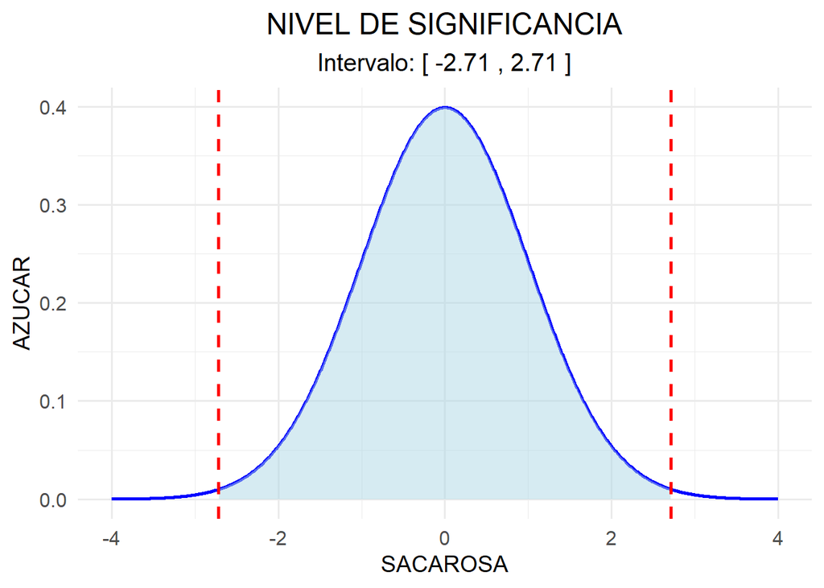

```r
cor.test(PD1$sacarosa,PD1$azucar,
                      method = "p",
                      alternative = "t",
                      conf.level = 0.97)$conf
```

```
## [1] 0.9164998 0.9974844
## attr(,"conf.level")
## [1] 0.97
```

El intervalo 0.9164998 0.9974844 brinda una confianza de 97% de contener a la correlacion entre el azucar y la sacarosa.

## Análisis de Regresión Lineal Simple

6. Estime la ecuación de la recta e interprete sus coeficientes.

```r
modelo <- lm(azucar ~ sacarosa, data = PD1)
modelo
```

```
##
## Call:
## lm(formula = azucar ~ sacarosa, data = PD1)
##
## Coefficients:
## (Intercept)     sacarosa
##     -1.9805       0.8948
```

Y = -1.9805 + 0.8948X b_0 = -1.9805 b_1 = 0.8948 Al incrementar la sacarosa en 1%, se espera que el numero medio de azucar se incremente en 0.8948%

```r
anova(modelo)
```

```
## Analysis of Variance Table
##
## Response: azucar
##           Df Sum Sq Mean Sq F value    Pr(>F)
## sacarosa   1 3.4028  3.4028  232.76 1.252e-06 ***
## Residuals  7 0.1023  0.0146
## ---
## Signif. codes:  0 '***' 0.001 '**' 0.01 '*' 0.05 '.' 0.1 ' ' 1
```

1. Planteo de hipotesis
   $$H_0 : \beta_0 =
   0$$
   $$H_1
   : \beta_1 \neq 0$$
2. Nivel de significancia
   $$\alpha =
   0.03$$
3. Estadistica de prueba

$$T = \frac{CMReg}{CME} \sim F_{1,
n-2}$$

4. Determinación de la región critica

```r
n <- nrow(PD1)
n
```

```
## [1] 9
```

```r
pf(0.03/2,1,n-2, lower.tail = F)
```

```
## [1] 0.9059653
```

```r
pf(232.76,1,7, lower.tail = F)
```

```
## [1] 1.251841e-06
```

A un $\alpha =0.03$ se puede afirmar que el porcentaje del azucar es explicado por el porcentaje de la sacarosa.

```r
summary(modelo)
```

```
##
## Call:
## lm(formula = azucar ~ sacarosa, data = PD1)
##
## Residuals:
##       Min        1Q    Median        3Q       Max
## -0.237664 -0.028127 -0.005644  0.065506  0.144440
##
## Coefficients:
##             Estimate Std. Error t value Pr(>|t|)
## (Intercept) -1.98053    0.65207  -3.037   0.0189 *
## sacarosa     0.89481    0.05865  15.257 1.25e-06 ***
## ---
## Signif. codes:  0 '***' 0.001 '**' 0.01 '*' 0.05 '.' 0.1 ' ' 1
##
## Residual standard error: 0.1209 on 7 degrees of freedom
## Multiple R-squared:  0.9708, Adjusted R-squared:  0.9666
## F-statistic: 232.8 on 1 and 7 DF,  p-value: 1.252e-06
```

8. Halle intervalos del 97% de confianza para $\beta_0$ y $\beta_1$.

```r
confint(modelo, level = 0.97)
```

```
##                 1.5 %     98.5 %
## (Intercept) -3.750631 -0.2104243
## sacarosa     0.735599  1.0540224
```

El intervalos 0.735599 1.0540224 brinda la confianza de contener $\beta_1$

1. Halle un intervalo del 97% de confianza para $\sigma_2$

```r
sig <- summary(modelo)$sigma
n <- nrow(PD1)
LI <- (n-2)*sig^2/qchisq(1-0.03/2,n-2)
LS <- (n-2)*sig^2/qchisq(0.03/2,n-2)
c(LI, LS)
```

```
## [1] 0.005881705 0.072144753
```

10. Halle e interprete el coeficiente de determinación.

```r
correlacion <- cor(PD1$sacarosa, PD1$azucar)
correlacion
```

```
## [1] 0.9852942
```

```r
determinacion <- correlacion^2
determinacion
```

```
## [1] 0.9708046
```

Coeficiente de correlación (r): 0.9852942 Coeficiente de determinación (R²): 0.9708046

Se interpretar que el 97% de la variabilidad en el porcentaje de azúcar puede ser explicada por la variabilidad en el porcentaje de sacarosa. Esto indica una relación lineal positiva fuerte entre ambas variables.

11. Halle un intervalo del 97% de confianza para el porcentaje medio azúcar por caña cuando se tiene un 12% de porcentaje de sacarosa por caña.

```r
summary(modelo)$ r.sq*100
```

```
## [1] 97.08046
```

```r
# 'modelo' es mi modelo de regresión
nueva_observacion <- data.frame(sacarosa = 12)

prediccion <- predict(modelo, newdata = nueva_observacion, interval = "confidence", level = 0.97)
prediccion
```

```
##        fit      lwr      upr
## 1 8.757201 8.576497 8.937906
```

Esto significa que con un 97% de confianza, podemos decir que el porcentaje de azucar con respecto a la sacarosa en 12% estara entre 8.576497 8.937906.